# Multiple regression

We use models to explain the relationship between variables and to make predictions. For now we will focus on **linear** models (but remember there are other types of models too!)

Today, we will focus on fitting and interpreting models with a continuous outcome variable and **multiple** predictors. This type of model is often called a **multivariable** (*not multivariate*) model. We will again be using functions from the `broom` package. In particular, we will be using the `augment` function to get model predictions and check assumptions for our linear regression model.

## Today’s data

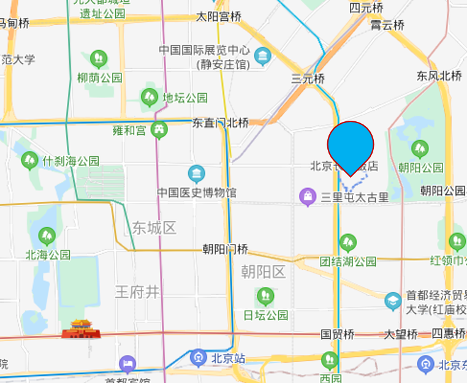

As a review, today’s data come from a series of atmospheric measurements taken at the Agriculture Exhibition Hall in Beijing from 2013 - 2017. The following variables are in the dataset:

- `year`, `month`, `day`, and `hour`: when the observation was taken
- `PM2.5` and `PM10`: levels of fine particulate matter in the atmosphere, in $\mu$g/m$^3$
- `SO2`, `NO2`, `CO`, `O3`: sulfur dioxide, nitrogen dioxide, carbon monoxide, and ozone concentrations, in $\mu$g/m$^3$, respectivel
- `TEMP`: temperature, in degrees C
- `PRES`: barometric pressure, in hPa
- `DEWP`: dew point temperature, in degrees C
- `RAIN`: precipitation levels, in mm
- `wd`: wind direction (eight compass directions)
- `SWPM`: wind speed, in m/s

These data are adapted from a dataset released by Song Xi Chen as referenced in Zhang S., et al (2017), Proc. Royal Soc. A. Let’s explore some of these data.

Last time, we created a linear model using ordinary least squares that predicts the dew point given the current barometric pressure, and interpreted the slope and intercept parameter estimates as follows:

```r
mod1 <- lm(DEWP ~ PRES, data = beijing)
tidy(mod1)
```

```
## # A tibble: 2 x 5
##   term        estimate std.error statistic   p.value
##   <chr>          <dbl>     <dbl>     <dbl>     <dbl>
## 1 (Intercept)  1071.     22.5         47.7 1.68e-302
## 2 PRES           -1.06    0.0222     -47.6 1.18e-301
```

We have a pretty good idea of what the dew point would be, **conditional** on the value of the barometric pressure. But if we knew the temperature and  
precipitation, we might do even better! Let’s add some more predictors to our model:

```r
mod2 <- lm(DEWP ~ PRES + TEMP + RAIN, data = beijing)
```

In general, the underlying linear model with multiple predictors is given by

$$y_i = \beta_0 + \beta_1 x_{1i} + \beta_2x_{2i} + \cdots + \beta_px_{pi} +
\epsilon_i$$

- $p$ is the total number of predictor or explanatory variables
- $y_i$ is the outcome variable for individual $i$
- $\beta_0$ is the intercept parameter
- $\beta_1, \beta_2, \cdots, \beta_p$ are the slope parameters
- $x_{1i}, \cdots, x_{pi}$ are the predictor variables
- $\epsilon_i$ is the unobserved error term

Interpretations for slope estimates are made **conditionally** on other predictors in the model. In this way, we can adjust for potential confounders in our model:

```
## # A tibble: 4 x 5
##   term        estimate std.error statistic   p.value
##   <chr>          <dbl>     <dbl>     <dbl>     <dbl>
## 1 (Intercept)  361.      36.1         9.99 8.29e- 23
## 2 PRES          -0.364    0.0353    -10.3  4.21e- 24
## 3 TEMP           0.723    0.0313     23.1  3.06e-101
## 4 RAIN           1.15     0.270       4.26 2.12e-  5
```

- If the barometric pressure, temperature, and precipitation are all 0, then we would expect a dew point of 361 degrees Celsius (hmm…)
- For each additional hPa increase in barometric pressure, we would expect a 0.364 C *decrease* in dew point (on average), **holding temperature and precipiation constant**
- For each additional degree C increase in temperature, we would expect a 0.723 C increase in dew point (on average), **holding barometric pressure and precipiation constant**
- For each additional mm increase in precipitation, we would expect a 1.15 C increase in dew point (on average), **holding barometric pressure and temperature constant**

We may again test hypotheses that $\beta$ coefficients are equal to 0 (vs. the alternative that they are not equal to 0). Be sure that any interpretation for slopes are made **conditionally** on the other predictors in the model (that is, holding them constant/adjusting for them, etc.). Under the null hypothesis, each slope coefficient should follow a $t$ distribution, with $n - p - 1$ degrees of freedom (where $n$ is the total sample size and $p$ is the number of estimated parameters in your model).

1. Is there sufficient evidence that barometric pressure has a linear association with dew point, while adjusting for temperature and precipitation?

We can once again `glance` at the model output to obtain model-specific summaries. Let’s take a look at the $R^2$ for our model:

```
## # A tibble: 1 x 11
##   r.squared adj.r.squared sigma statistic p.value    df logLik    AIC    BIC
##       <dbl>         <dbl> <dbl>     <dbl>   <dbl> <int>  <dbl>  <dbl>  <dbl>
## 1     0.708         0.707  7.55     1209.       0     4 -5158. 10327. 10353.
## # ... with 2 more variables: deviance <dbl>, df.residual <int>
```

We see that approximately 70% of the variability in dew point explained by its linear relationship with barometric pressure, temperature, and dew point, which is higher than the 60% explained by barometric pressure alone.

However, $R^2$ can never decrease when variables are added to a model, *even if they are useless for prediction*. We adjust for the number of predictors in our model to obtain **adjusted** $R^2$, where the adjustment is made to account for the number of predictors. $R^2_{adj}$ incorporates a penalty for each additional predictor, so it will go down if a new variable does not meaningfully improve prediction. However, note that $R^2_{adj}$ can **not** be interpreted as explained variability.

## Predicting new values

Our fitted model is given by

```
## # A tibble: 4 x 2
##   term        estimate
##   <chr>          <dbl>
## 1 (Intercept)  361.
## 2 PRES          -0.364
## 3 TEMP           0.723
## 4 RAIN           1.15
```

$$\widehat{DEWP} = 360.7 - 0.36PRES + 0.72 TEMP + 1.15RAIN,$$

and can be used to predict dew points given the barometric pressure, temperature, and precipitation (simply plug into the model). Try to answer the following question, which will require some `dplyr` manipulation:

2. Suppose the barometric pressure, temperature, and precipitation are equal to the mean values in our dataset. What would the predicted dew point be?
3. Is this prediction close to the mean dew point in our dataset?

We can actually obtain the predicted values using code, without having to deal with messy algebra. We will use the `augment` function. Let’s try it out on our model object:

```
## # A tibble: 1,500 x 11
##     DEWP  PRES  TEMP  RAIN .fitted .se.fit  .resid    .hat .sigma .cooksd
##    <dbl> <dbl> <dbl> <dbl>   <dbl>   <dbl>   <dbl>   <dbl>  <dbl>   <dbl>
##  1 -15.1 1025.   0.5     0 -11.6     0.306  -3.52  1.65e-3   7.55 9.00e-5
##  2 -12.8 1022.  -2.2     0 -12.6     0.339  -0.178 2.01e-3   7.55 2.82e-7
##  3 -11.6 1018.  -5.2     0 -13.4     0.471   1.81  3.89e-3   7.55 5.64e-5
##  4 -12.2 1017.   7.1     0  -3.86    0.225  -8.34  8.92e-4   7.55 2.73e-4
##  5 -14.2 1020.   6       0  -5.89    0.242  -8.31  1.02e-3   7.55 3.11e-4
##  6 -14.3 1022.  11.5     0  -2.71    0.348 -11.6   2.12e-3   7.54 1.26e-3
##  7  -7   1010.   5.6     0  -2.65    0.375  -4.35  2.46e-3   7.55 2.05e-4
##  8  -6.6 1011.   8.4     0  -0.772   0.294  -5.83  1.52e-3   7.55 2.27e-4
##  9  -6.2 1010.   8.8     0  -0.337   0.295  -5.86  1.53e-3   7.55 2.31e-4
## 10  -4.6 1007   14.7     0   5.17    0.261  -9.77  1.19e-3   7.55 5.00e-4
## # ... with 1,490 more rows, and 1 more variable: .std.resid <dbl>
```

Notice that the `augment` function provides fitted values and residuals (and more) for every observation in our dataset.

The mean pressure, temperature, and precipitation in our dataset are 1012.6 hPa, 13.55 C, and 0.074 mm, respectively (did you obtain these results using the `summarize` function in a pipeline?). Let’s create a new `tibble` and “feed” it into our `mod2` model object, which contains our multiple linear regression model:

```r
mean_vals = tibble(PRES = 1012.6,
                    TEMP = 13.55,
                    RAIN = 0.074)
augment(mod2, newdata = mean_vals)
```

```
## # A tibble: 1 x 5
##    PRES  TEMP  RAIN .fitted .se.fit
##   <dbl> <dbl> <dbl>   <dbl>   <dbl>
## 1 1013.  13.6 0.074    2.38   0.195
```

Note that the new dataset has the same variable names as found in our model. With our model we predict a dew point of 2.38 C and note that the standard error for this prediction is 0.195 C.

4. How might we use these results to create interval estimates?

## Model assumptions

So far, we have blindly fit linear models without caring about any assumptions. However, like all statistical techniques, there are a few main assumptions to the linear model:

- The outcomes $y_i$ are **independent**. This means that observations do not “influence” each other in any way (e.g., repeated outcome measures are made on the same individual)
- A **linear relationship** holds (though we can relax this to some extent)
- The **error** terms are normally distributed, with mean zero and constant variance across all predicted/fitted values

Many of the assumptions deal with the error term and fitted values, which we might estimate using the residuals and predictions from our model. Luckily, we can use the `augment` function from the `broom` package to calculate these. Let’s consider the multiple regression model from earlier, focusing on the `.fitted` and `.resid` variables in this data frame:

```r
augment(mod2) %>%
  select(.fitted, .resid)
```

```
## # A tibble: 1,500 x 2
##    .fitted  .resid
##      <dbl>   <dbl>
##  1 -11.6    -3.52
##  2 -12.6    -0.178
##  3 -13.4     1.81
##  4  -3.86   -8.34
##  5  -5.89   -8.31
##  6  -2.71  -11.6
##  7  -2.65   -4.35
##  8  -0.772  -5.83
##  9  -0.337  -5.86
## 10   5.17   -9.77
## # ... with 1,490 more rows
```

- `.fitted` provides the predicted value of the response variable (for the given observation)
- `.resid` provides the residual for the observation

### Evaluating independence

Unfortunately, in many cases we must simply think about how the data are collected. In this case, we have atmospheric measurements through time at a single station. Independence might **not** be satisfied – we might imagine that if the dew point is high today, it’ll probably still be high tomorrow. Note that the data are already sorted in chronological order. Let’s plot the dew point through time, examining the first three hundred data points:

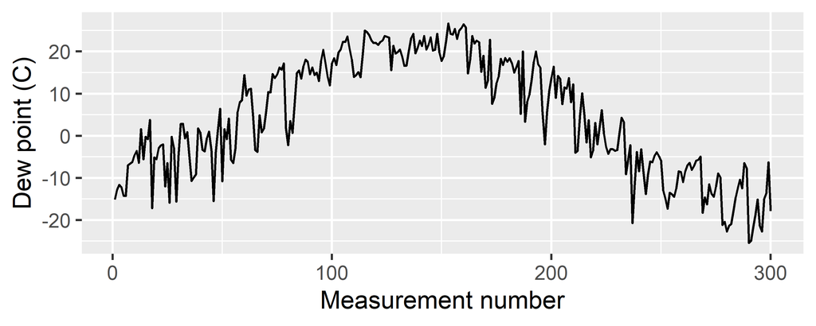

```r
beijing %>%
  slice(1:300) %>%
  ggplot(data = ., mapping = aes(x = 1:300, y = DEWP)) +
  geom_line() +
  labs(x = "Measurement number", y = "Dew point (C)")
```

We see that independence is violated. Although we used a graph to help us determine this visually, this was only because our data happened to be time- series data. In general, there is no plot that we will always be able to use to diagnose independence.

### Evaluating normality of errors

We can simply plot a histogram of the residuals and assess visually. There are more formal methods, but for our purposes this will suffice. Note our use of the `.resid` variable from the augmented model results:

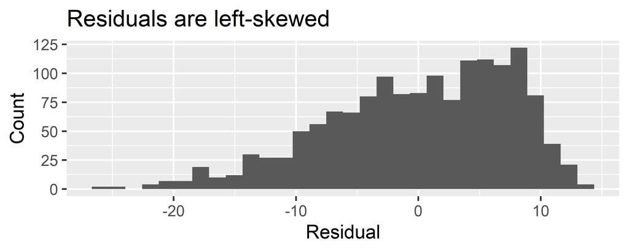

```r
augment(mod2) %>%
  ggplot(data = ., mapping = aes(x = .resid)) +
  geom_histogram() +
  labs(x = "Residual", y = "Count",
       title = "Residuals are left-skewed")
```

5. Do the residuals appear to be normally distributed?

### The residual plot

One of the most useful diagnostic plots is the **residual plot**, which plots the fitted values against the residuals. Let’s take a look:

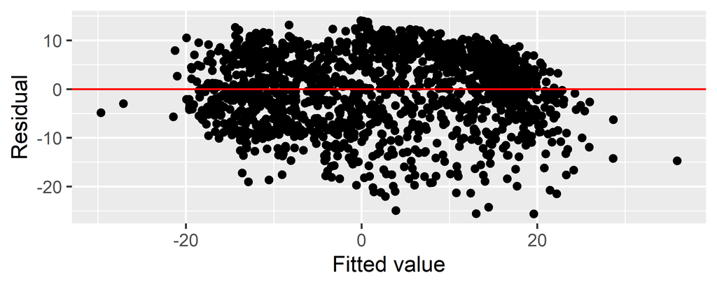

```r
augment(mod2) %>%
  ggplot(data = ., mapping = aes(x = .fitted, y = .resid)) +
  geom_point() +
  geom_hline(yintercept = 0, color = "red") +
  labs(x = "Fitted value", y = "Residual")
```

Ideally, the residual plot should be a “shapeless blob” with no real pattern. A pattern would be indicative of potential violation of our model assumptions.

- If the residuals are not symmetric about the x-axis, then we might have violation of linearity. This appears to be the case in our residual plot
- If the residuals do not have similar vertical spread for all fitted values, then we might have violation of constant error variance (homoscedasticity of errors). This might result in a “fanning” pattern. Our residual plot doesn’t suggest that this assumption violated.
6. Do linearity and homogeneity of error variance appear satisfied in our plot? Why or why not?

## Interaction effects

Sometimes, the effect of one variable depends on the value of another. For example, the effect of exercise % on obesity may be different for smokers vs. non-smokers. To model such a relationship, we create an **interaction term**.

For a given PRES, TEMP, and RAIN, our predicted DEWP is given by
$$\begin{align*}
\widehat{DEWP} &= \hat{\beta}_0 + \hat{\beta}_1PRES + \hat{\beta}_2TEMP +\\
&\mathrel{\phantom{=}} \hat{\beta}_3RAIN + \hat{\beta}_4TEMP \times RAIN
\end{align*}$$

For a day with the same PRES AND TEMP but one higher unit of RAIN, the predicted DEWP is given by
$$\begin{align*}
\widehat{DEWP}^\star &= \hat{\beta}_0 + \hat{\beta}_1PRES + \hat{\beta}_2TEMP +\\
&\mathrel{\phantom{=}} \hat{\beta}_3(RAIN + 1) + \hat{\beta}_4TEMP \times (RAIN + 1)
\end{align*}$$

Subtracting the two equations, we have
$$\widehat{DEWP} - \widehat{DEWP}^\star = \hat{\beta}_3 + \hat{\beta}_4 TEMP$$
The expected change in dew point for a one mm increase in precipitation, if pressure is held constant, is $\hat{\beta}_3 + \hat{\beta}_4 \times TEMP$

**The effect of precipitation on the dew point, adjusting for pressure, depends on temperature!**

Let’s take a look at the tidy output:

```r
tidy(mod3)
```

```
## # A tibble: 5 x 5
##   term        estimate std.error statistic   p.value
##   <chr>          <dbl>     <dbl>     <dbl>     <dbl>
## 1 (Intercept)  361.      36.0        10.0  5.58e- 23
## 2 PRES          -0.364    0.0352    -10.3  2.73e- 24
## 3 TEMP           0.725    0.0312     23.2  4.31e-102
## 4 RAIN           9.01     2.65        3.40 6.97e-  4
## 5 TEMP:RAIN     -0.354    0.119      -2.98 2.93e-  3
```

7. What **is** the estimated expected change in dew point given a one mm increase in precipitation? (Hint: as stated before, it depends on the temperature!)
8. Recently, atmospheric pollution in terms of fine particulate matter (PM2.5) has been of concern. Fit a model that predicts PM2.5 levels based on current weather patterns.
9. Assess any assumptions needed for your linear model.
10. Is there evidence that any weather-related variables are linearly associated with PM2.5 levels, conditional on levels of the other predictors?